# Generate figures in Real Data Analysis: Melanoma

Yunqing Liu & Ningshan Li

2023/09/09

# 1 Summary

This R Notebook generates figures for **Melanoma** dataset in Real Data Analysis section in manuscript.

1. **Inputs**:
- [`Melanoma_spatial_spot_nUMI.csv`](https://github.com/az7jh2/SDePER_Analysis/blob/main/RealData/Melanoma/Melanoma_spatial_spot_nUMI.csv): nUMI of all 16,148 genes across all 293 spatial spots in Melanoma dataset.
- [`Melanoma_all_results.rds`](https://github.com/az7jh2/SDePER_Analysis/blob/main/Figures/Melanoma/Melanoma_all_results.rds): cell type deconvolution results of all methods, as well as the cell type annotation in Melanoma data analysis.
- Imputation results of SDePER and CARD at 3 different levels of resolution can be found in folder [Melanoma](https://zenodo.org/record/8334656/files/Melanoma.zip) in 10.5281/zenodo.8334655.
2. **Outputs**:
- Figure 4A. Visualization of Melanoma dataset
- Figure 4B. Visualization of inferred dominant cell type in each spot
- Figure 4C. Visualization of inferred cell type proportions in each spot
- Figure 4D. Barplot of ARI and purity of all methods
- Figure 4E. Heatmap of original and imputed expression of 4 region-specific marker genes
- Figure 4F. Heatmap of average imputed expression of 4 region-specific marker genes at 80 μm level
- Figure 4G. Barplot of ratio of average imputed expression of 4 region-specific marker genes at 80 μm level
- Figure S14. Heatmap of 7 cell type-specific marker genes
- Figure S16. Heatmap of estimated and imputed cell type proportions by SDePER and CARD
- Figure S17. Heatmap of imputed expression of 4 region-specific marker genes by SDePER and CARD

# 2 Version

```r
version[['version.string']]
```

```
[1] "R version 4.2.2 Patched (2022-11-10 r83330)"
```

```r
print(sprintf('Package %s version: %s', 'ggplot2', packageVersion('ggplot2')))
```

```
[1] "Package ggplot2 version: 3.4.2"
```

```r
print(sprintf('Package %s version: %s', 'ggpubr', packageVersion('ggpubr')))
```

```
[1] "Package ggpubr version: 0.6.0"
```

```r
print(sprintf('Package %s version: %s', 'pdfCluster', packageVersion('pdfCluster'))) # ARI function
```

```
[1] "Package pdfCluster version: 1.0.4"
```

```r
print(sprintf('Package %s version: %s', 'funtimes', packageVersion('funtimes'))) # purity function
```

```
[1] "Package funtimes version: 9.1"
```

```r
print(sprintf('Package %s version: %s', 'CARD', packageVersion('CARD'))) # Visualization function
```

```
[1] "Package CARD version: 1.1"
```

# 3 Read relevant files

## 3.1 Read gene expression of spatial spots

```r
file_name = file.path(home.dir, 'Melanoma_spatial_spot_nUMI.csv')
gene_numi = read.csv(file_name, row.names = 1, check.names = F)
print(sprintf('load data from %s', file_name))
```

```
[1] "load data from /home/hill103/Documents/Spatial/Figures/Melanoma/Melanoma_spatial_spot_nUMI.csv"
```

```r
print(sprintf('genes: %d, spots: %d', ncol(gene_numi), nrow(gene_numi)))
```

```
[1] "genes: 16148, spots: 293"
```

```r
# transpose it to meet the need of CARD
gene_numi = as.data.frame(t(gene_numi))
```

## 3.2 Read estimated cell type proportions by all methods

NOTE: cell type deconvolution results from **RCTD**, **SpatialDWLS**, **CARD**, **SONAR** and **DestVI** are 1 spot fewer than all 293 spatial spots.

```r
file_name = file.path(home.dir, 'Melanoma_all_results.rds')
all_res = readRDS(file_name)
print(sprintf('load data from %s', file_name))
```

```
[1] "load data from /home/hill103/Documents/Spatial/Figures/Melanoma/Melanoma_all_results.rds"
```

```r
# check the order of spatial spots and cell types are consistent
all_spots = row.names(all_res[['Annotation']])
all_celltypes = colnames(all_res[['SDePER']])
```

Check the order of spots and cell types are consistent before performance evaluation.

```r
for (method_name in all_methods) {
  if (method_name %in% c('RCTD', 'SONAR', 'SpatialDWLS', 'CARD', 'DestVI')) {
    stopifnot(all(row.names(all_res[[method_name]]) == row.names(all_res[['SpatialDWLS']])))
  } else {
    stopifnot(all(row.names(all_res[[method_name]]) == all_spots))
  }
  stopifnot(all(colnames(all_res[[method_name]]) == all_celltypes))
}
```

Check whether negative values of estimated cell type proportions exist. Replace them as 0.

```r
for (method_name in all_methods) {
  tmp_df = all_res[[method_name]]
  for (i in 1:nrow(tmp_df)) {
    for (j in 1:ncol(tmp_df)) {
      if (tmp_df[i, j] < 0) {
        print(sprintf('%s result: row %d (%s) column %d (%s) has negative value %g', method_name, i, row.names(tmp_df)[i], j, colnames(tmp_df)[j], tmp_df[i, j]))
        # replace them with 0
        all_res[[method_name]][i, j] = 0
      }
    }
  }
}
```

Calculate dominant cell type for each spot.

```r
all_res_dominat = list()

for (method_name in all_methods) {
  tmp_df = all_res[[method_name]]
  for (i in 1:nrow(tmp_df)) {
    this_row_max_col = which.max(tmp_df[i, ])
    tmp_df[i, this_row_max_col] = 1
    tmp_df[i, -this_row_max_col] = 0
  }
  stopifnot(all(rowSums(tmp_df) == 1))
  all_res_dominat[[method_name]] = tmp_df
}
```

## 3.3 Read imputation results by SDePER and CARD

NOTE: In SDePER we define **1 µm = 10 pixels**, and output the imputed spots **at pixel unit**. For Melanoma, the distance between two neighboring spatial spots is 200 µm. So to convert pixel to axis coordinates, we divided the (x,y) locations of imputed spots by 2,000.

NOTE: The imputed gene expressions are sequencing depth normalized values.

```r
# nested list with names are diameter (80/114/160) and data type (celltype/gene/loc)
imputations = list()

for (method_name in impute_methods) {
  imputations[[method_name]] = list()
  for (this_diameter in impute_diameters) {
    imputations[[method_name]][[this_diameter]] = list()
    for (this_datatype in impute_file_types) {
      imputations[[method_name]][[this_diameter]][[this_datatype]] = read.csv(file.path(home.dir,
                                                                                        sprintf('%s_%s_imputation_results_diameter_%s', impute_dataset, method_name, this_diameter),
                                                                                        sprintf('%s_impute_diameter_%s_spot_%s.csv', method_name, this_diameter, this_datatype)),
                                                                              row.names = 1, check.names = F)
    }
  }
}

# check order of spots, NOTE the gene expression dataframe is rows as genes and columns as spots
for (method_name in names(imputations)) {
  for (this_diameter in names(imputations[[method_name]])) {
    print(sprintf('Method %s - imputation at resolution %s μm: spots %d', method_name, this_diameter, nrow(imputations[[method_name]][[this_diameter]][['celltype_prop']])))
    stopifnot(all(row.names(imputations[[method_name]][[this_diameter]][['celltype_prop']]) == colnames(imputations[[method_name]][[this_diameter]][['gene_norm_exp']])))
    stopifnot(all(row.names(imputations[[method_name]][[this_diameter]][['celltype_prop']]) == row.names(imputations[[method_name]][[this_diameter]][['loc']])))

    # convert pixel to axis coordinates by divided by 2000
    if (method_name == 'SDePER') {
      imputations[[method_name]][[this_diameter]][['loc']] = imputations[[method_name]][[this_diameter]][['loc']] / 2000
    }
  }
}
```

```
[1] "Method SDePER - imputation at resolution 80 μm: spots 1717"
[1] "Method SDePER - imputation at resolution 114 μm: spots 828"
[1] "Method SDePER - imputation at resolution 160 μm: spots 410"
[1] "Method CARD - imputation at resolution 80 μm: spots 1663"
[1] "Method CARD - imputation at resolution 114 μm: spots 845"
[1] "Method CARD - imputation at resolution 160 μm: spots 417"
```

Annotate the layer of imputed spots based on Euclidean distance. For one imputed spot, its layer annotation is the same as the layer annotation of the closest spot at original resolution. If multiple closest spots with same distance exist, pick the most frequent layer among these spots.

```r
for (method_name in names(imputations)) {
  for (this_diameter in names(imputations[[method_name]])) {
    tmp_df = imputations[[method_name]][[this_diameter]][['loc']]
    tmp_df$anno = ''
    tmp_dis = as.matrix(pdist::pdist(as.matrix(tmp_df[, c('x', 'y')]), as.matrix(all_res[['Annotation']][, c('x', 'y')])))
    for (i in 1:nrow(tmp_df)) {
      # find all spots at original resolution with min distance
      tmp_ind = which(tmp_dis[i, ] == min(tmp_dis[i, ]))
      if (length(tmp_ind) == 1) {
        tmp_df[i, 'anno'] = all_res[['Annotation']][tmp_ind, 'anno']
      } else {
        # count frequency
        tmp_anno_freq = table(all_res[['Annotation']][tmp_ind, 'anno', drop=T])
        tmp_max_freq_anno = names(tmp_anno_freq[tmp_anno_freq==max(tmp_anno_freq)])
        if (length(tmp_max_freq_anno) == 1) {
          tmp_df[i, 'anno'] = tmp_max_freq_anno
        } else {
          print(sprintf('WARNING: %s + %s μm: %d-th spot matches %d frequent annotations (%s). Now pick %s', method_name, this_diameter, i, length(tmp_max_freq_anno), paste(tmp_max_freq_anno, collapse = ','), tmp_max_freq_anno[1]))
          tmp_df[i, 'anno'] = tmp_max_freq_anno[1]
        }
      }
    }
    imputations[[method_name]][[this_diameter]][['loc']] = tmp_df
  }
}
```

```
[1] "WARNING: SDePER + 80 μm: 677-th spot matches 2 frequent annotations (LT 2,Melanoma). Now pick LT 2"
[1] "WARNING: SDePER + 80 μm: 726-th spot matches 2 frequent annotations (LT 2,Melanoma). Now pick LT 2"
[1] "WARNING: SDePER + 160 μm: 171-th spot matches 2 frequent annotations (LT 2,Melanoma). Now pick LT 2"
[1] "WARNING: CARD + 80 μm: 104-th spot matches 2 frequent annotations (LT 2,Melanoma). Now pick LT 2"
[1] "WARNING: CARD + 80 μm: 106-th spot matches 2 frequent annotations (LT 2,Melanoma). Now pick LT 2"
[1] "WARNING: CARD + 114 μm: 315-th spot matches 2 frequent annotations (LT 2,Melanoma). Now pick LT 2"
[1] "WARNING: CARD + 114 μm: 347-th spot matches 2 frequent annotations (LT 2,Melanoma). Now pick LT 2"
[1] "WARNING: CARD + 114 μm: 349-th spot matches 2 frequent annotations (LT 2,Stroma). Now pick LT 2"
[1] "WARNING: CARD + 114 μm: 350-th spot matches 2 frequent annotations (LT 2,Stroma). Now pick LT 2"
[1] "WARNING: CARD + 114 μm: 383-th spot matches 2 frequent annotations (LT 2,Melanoma). Now pick LT 2"
[1] "WARNING: CARD + 114 μm: 425-th spot matches 2 frequent annotations (LT 2,Melanoma). Now pick LT 2"
[1] "WARNING: CARD + 114 μm: 466-th spot matches 2 frequent annotations (LT 2,Melanoma). Now pick LT 2"
```

Calculate average imputed expression levels of each region marker gene (*PMEL* for Melanoma, *COL1A1* for Stroma, *CXCL10* for LT 2, *MS4A1* for LT 1).

```r
avg_exp_layer = list()

for (method_name in names(imputations)) {
  avg_exp_layer[[method_name]] == list()
  for (this_diameter in names(imputations[[method_name]])) {
    tmp_df = merge(imputations[[method_name]][[this_diameter]][['loc']][, 'anno', drop=F], t(imputations[[method_name]][[this_diameter]][['gene_norm_exp']][unname(mela_layer_marker), ]), by = 'row.names')
    # calculate average expression of layer markers in each layer
    tmp_df = tmp_df %>%
      select(all_of(c('anno', unname(mela_layer_marker)))) %>%
      filter(anno %in% layer_order) %>%
      group_by(anno) %>%
      summarise(across(.cols=everything(), .fns=mean, .names="{.col}"))
    # standardize expression of each marker gene across all layers to mean 0 and standard deviation 1
    tmp_df = tidyr::gather(tmp_df, marker, expression, -anno, factor_key=F)
    tmp_df = tmp_df %>%
      group_by(marker) %>%
      mutate(scaled_exp=as.vector(scale(expression)))
    tmp_df['Method'] = method_name

    avg_exp_layer[[method_name]][[this_diameter]] = tmp_df
  }
}
```

# 4 Evaluate performance of cell type deconvolution methods

We use **ARI** (adjusted Rand index) and **purity** to quantitative assessment of the similarity between the predicted **dominant cell type** and H&E staining image-based annotation.

```r
perform_df = data.frame(matrix(ncol=3, nrow=0))
colnames(perform_df) = c('Method', 'ARI', 'Purity')

for (method_name in all_methods) {
  this_ari = pdfCluster::adj.rand.index(all_res[['Annotation']][row.names(all_res_dominat[[method_name]]), 'anno', drop=T],
                                        apply(all_res_dominat[[method_name]], 1, function(row) {
                                          names(row)[which(row == 1)]}
                                        ))
  this_purity = funtimes::purity(all_res[['Annotation']][row.names(all_res_dominat[[method_name]]), 'anno', drop=T],
                                 apply(all_res_dominat[[method_name]], 1, function(row) {
                                   names(row)[which(row == 1)]}
                                 ))$pur
  perform_df[nrow(perform_df)+1, ] = c(method_name, this_ari, this_purity)
}

perform_df$ARI = as.numeric(perform_df$ARI)
perform_df$Purity = as.numeric(perform_df$Purity)
```

# 5 Draw figures

We use visualization functions in CARD to draw the heatmaps of gene expression and pie chart.

NOTE:

- `CARD.visualize.gene` will normalize the gene expression within each spot by sequencing depth, then further normalize expression to [0, 1] across all spots. If the input gene expression is already sequencing depth-normalized expression values, it does not hurt to normalize by sequencing depth again.
- `CARD.visualize.gene` use `geom_point` to draw heatmaps. If the size of the points is smaller than the plotting area allocated for each point, discontinuities or blanks between neighboring points will be observed.
- but for `geom_tile`, the default tile size is 1, and it only support integer coordinates, so not used here.
- `CARD.visualize.prop` will **scale proportions of each cell type across all spots to [0, 1]**, which is not what we desire, So we define a custom visualization function with CARD style for visualizing cell type proportions.

## 5.1 Figure 4A. Visualization of Melanoma dataset

Annotation of 4 annotation regions.

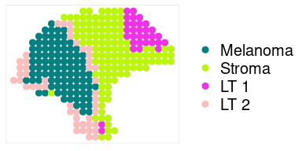

```r
if (save_file) {
  file_name = file.path(home.dir, 'Fig4A_Melanoma_region_annotation.pdf')
  cairo_pdf(file_name, height=2, width=4, onefile=T)
  print(sprintf('figures saved in file %s', file_name))
}

plot_df = all_res[['Annotation']]
plot_df$anno = factor(plot_df$anno, levels = c("Melanoma", "Stroma", "LT 1", "LT 2"))

ggplot(plot_df, aes(x=x, y=y, color=anno)) +
  geom_point(size=2.5) +
  coord_fixed(ratio = 1) +
  scale_color_manual(values = anno_color) +
  theme_classic() +
  theme(plot.margin = margin(0.1, 0.1, 0.1, 0.1, "cm"),
        panel.border = element_rect(colour = "grey89", fill = NA, size = 0.5), # add a border to plot
        axis.text = element_blank(), axis.ticks = element_blank(), axis.title = element_blank(), axis.line = element_blank(),
        legend.text = element_text(size = 15)) +
  guides(color = guide_legend(title = NULL))
```

Heatmap of 4 cell type-specific marker genes: *PMEL* for malignant melanoma region, *COL1A1* for fibroblast in stroma resion, *CD14* for macrophage, and *MS4A1* for B cells.

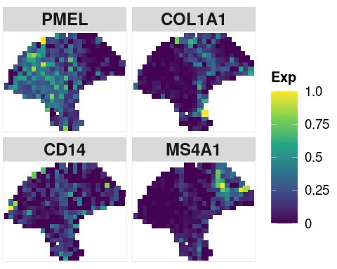

```r
if (save_file) {
  file_name = file.path(home.dir, 'Fig3A_Melanoma_4celltype_marker_heatmap.pdf')
  cairo_pdf(file_name, height=4, width=5, onefile=T)
  print(sprintf('figures saved in file %s', file_name))
}

# CARD visualization functions require spatial gene expression dataframe is raw nUMI counts with rows as genes and columns as spots, as the visualization function will normalize nUMI counts by sequencing depth of spots
CARD::CARD.visualize.gene(
  spatial_expression = gene_numi[, rownames(all_res[['Annotation']])],
  spatial_location = all_res[['Annotation']][, c('x', 'y')],
  gene.visualize = mela_celltype_marker,
  colors = NULL,
  NumCols = 2) + theme(legend.position="right") + guides(color=guide_colourbar(title="Exp")) +
  geom_point(aes(color=value), size=3, shape=15, position=position_dodge2(width=0.05))
```

## 5.2 Figure S14. Heatmap of 7 cell type-specific marker genes

*PMEL* for malignant melanoma, *COL1A1* for CAF, *C1QC* for macrophage, *MS4A1* for B cell, *CD2* for T cell, *GNLY* for NK cell, and *VWF* for endothelial cell.

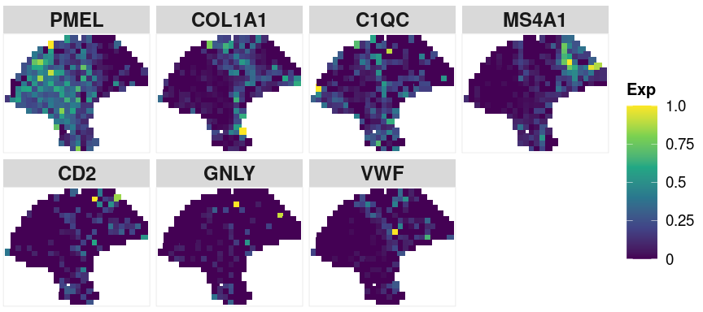

```r
if (save_file) {
  file_name = file.path(home.dir, 'FigS14_Melanoma_7celltype_marker_heatmap.pdf')
  cairo_pdf(file_name, height=4, width=9, onefile=T)
  print(sprintf('figures saved in file %s', file_name))
}

# CARD visualization functions require spatial gene expression dataframe is raw nUMI counts with rows as genes and columns as spots, as the visualization function will normalize nUMI counts by sequencing depth of spots
CARD::CARD.visualize.gene(
  spatial_expression = gene_numi[, rownames(all_res[['Annotation']])],
  spatial_location = all_res[['Annotation']][, c('x', 'y')],
  gene.visualize = c('PMEL', 'COL1A1' ,'C1QC', 'MS4A1', 'CD2', 'GNLY', 'VWF'),
  colors = NULL,
  NumCols = 4) + theme(legend.position="right") + guides(color=guide_colourbar(title="Exp")) +
  geom_point(aes(color=value), size=3, shape=15, position=position_dodge2(width=0.05))
```

## 5.3 Figure 4B. Visualization of inferred dominant cell type in each spot

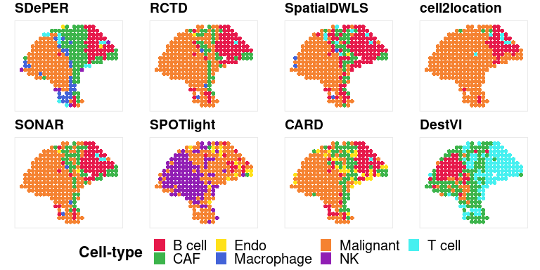

```r
if (save_file) {
  file_name = file.path(home.dir, 'Fig4B_Melanoma_piechart_dominant_celltype.pdf')
  cairo_pdf(file_name, height=4, width=8, onefile=T)
  print(sprintf('figures saved in file %s', file_name))
}

g_list = list()

for (method_name in all_methods) {
  g_list[[method_name]] = CARD::CARD.visualize.pie(
    proportion = all_res_dominat[[method_name]],
    spatial_location = all_res[['Annotation']][row.names(all_res_dominat[[method_name]]), c('x', 'y')],
    colors = melanoma_color, radius=0.55) +
      theme(legend.position="bottom", title=element_text(face=2, size=12)) +
      scale_fill_manual(values=melanoma_color, breaks=names(melanoma_color), labels=celltype_label) +
      guides(fill=guide_legend(title="Cell-type")) +
      ggtitle(method_name)
}

ggpubr::ggarrange(plotlist = g_list, ncol = 4, nrow = 2, align = 'hv', common.legend = T, legend = 'bottom')
```

## 5.4 Figure 4C. Visualization of inferred cell type proportions in each spot

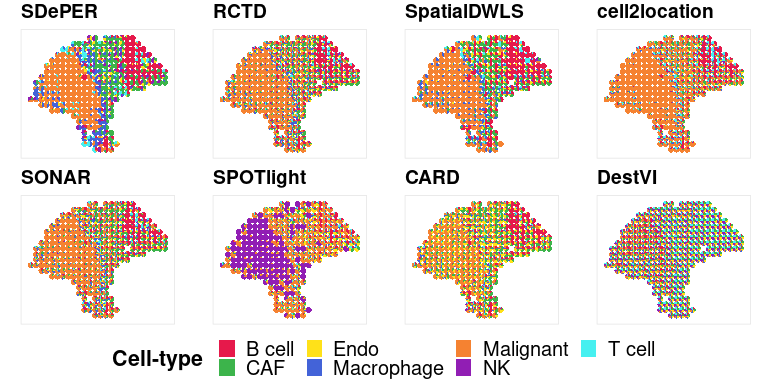

```r
if (save_file) {
  file_name = file.path(home.dir, 'Fig4C_Melanoma_piechart_celltype_props.pdf')
  cairo_pdf(file_name, height=4, width=8, onefile=T)
  print(sprintf('figures saved in file %s', file_name))
}

g_list = list()

for (method_name in all_methods) {
  g_list[[method_name]] = CARD::CARD.visualize.pie(
    proportion = all_res[[method_name]],
    spatial_location = all_res[['Annotation']][row.names(all_res[[method_name]]), c('x', 'y')],
    colors = melanoma_color, radius=0.55) +
      theme(legend.position="bottom", title=element_text(face=2, size=12)) +
      scale_fill_manual(values=melanoma_color, breaks=names(melanoma_color), labels=celltype_label) +
      guides(fill=guide_legend(title="Cell-type")) +
      ggtitle(method_name)
}

ggpubr::ggarrange(plotlist = g_list, ncol = 4, nrow = 2, align = 'hv', common.legend = T, legend = 'bottom')
```

## 5.5 Figure 4D. Barplot of ARI and purity of all methods

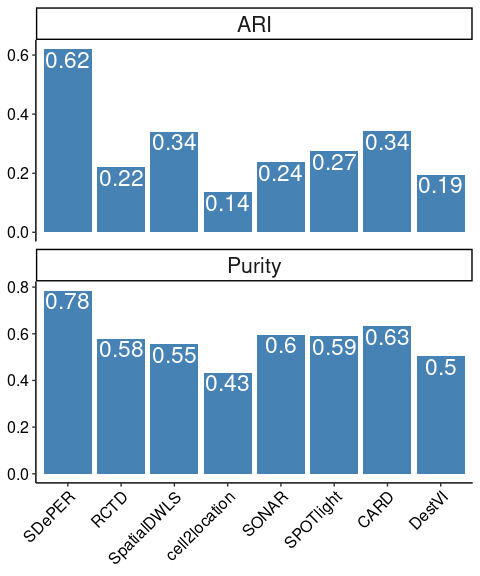

```r
if (save_file) {
  file_name = file.path(home.dir, 'Fig4D_Melanoma_barplot_performance.pdf')
  cairo_pdf(file_name, height=6, width=5, onefile=T)
  print(sprintf('figures saved in file %s', file_name))
}

plot_df = tidyr::gather(perform_df, measure, value, ARI, Purity)
plot_df$Method = factor(plot_df$Method, levels = all_methods)

ggplot(plot_df, aes(x=Method, y=value)) +
  geom_bar(stat="identity", fill="steelblue") +
  geom_text(aes(label=round(value, 2), y=ifelse(value<0.1, value+0.07, value), color=ifelse(value<0.1, "black", "white")), vjust=1.1, size=6) +
  theme_classic() +
  theme(axis.text = element_text(color="black", size=12),
        strip.text = element_text(size=16),
        axis.title = element_blank(),
        axis.text.x = element_text(angle=45, hjust=1)) +
  facet_wrap(measure~., ncol=1, scales="free_y") +
  scale_color_identity() # to make sure ggplot2 uses the set conditional colors
```

## 5.6 Figure S16. Heatmap of estimated and imputed cell type proportions by SDePER and CARD

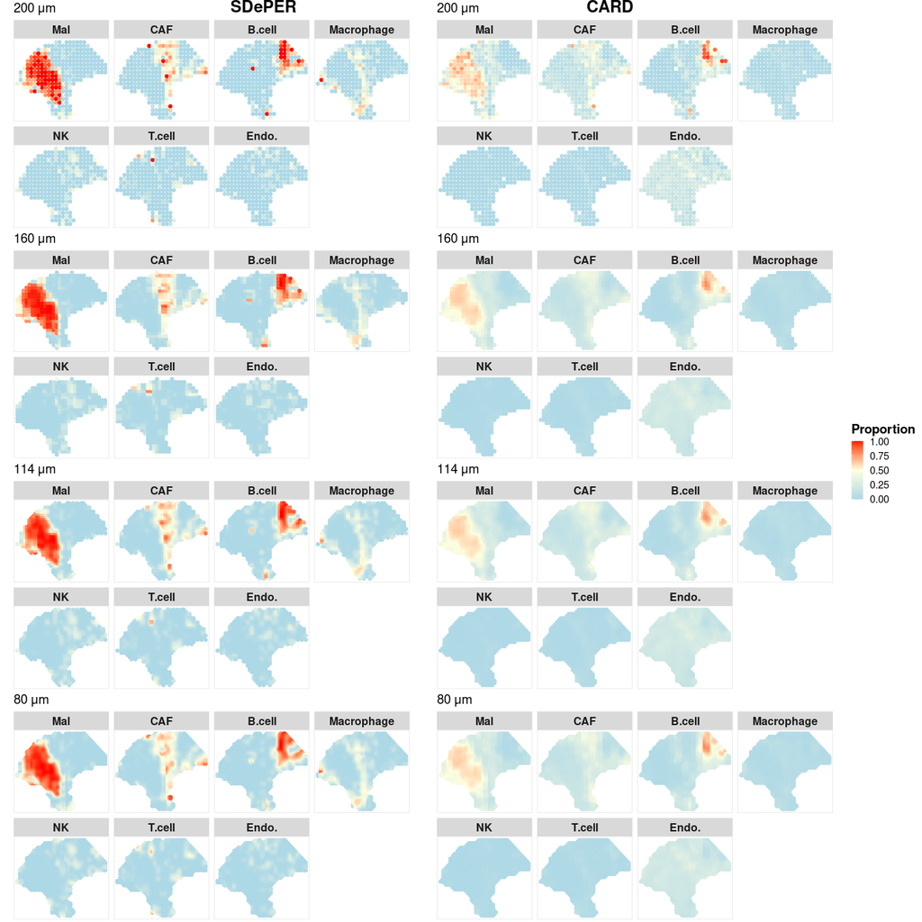

```r
if (save_file) {
  file_name = file.path(home.dir, 'FigS16_Melanoma_celltype_prop_heatmap_impute.pdf')
  cairo_pdf(file_name, height=14, width=14, onefile=T)
  print(sprintf('figures saved in file %s', file_name))
}

# first define a custom function to visualize cell type proportion
visualize.prop = function(proportion, location, celltypes, NumCols, pointSize=3.0) {

  stopifnot(all(row.names(proportion) == row.names(location)))

  plot_data = merge(proportion[, celltypes], location[, c('x', 'y')], by='row.names') %>%
    select(all_of(c('x', 'y', celltypes)))
  plot_data = tidyr::gather(plot_data, celltype, prop, all_of(celltypes), factor_key=F)
  plot_data$celltype = factor(plot_data$celltype, levels = celltypes)

  g = ggplot(plot_data, aes(x, y)) +
    geom_point(aes(colour = prop), size = pointSize) +
    scale_color_gradientn(colours = c("lightblue", "lightyellow", "red"), limits = c(0, 1)) +
    scale_x_discrete(expand = c(0, 1)) + scale_y_discrete(expand = c(0, 1)) +
    facet_wrap(~celltype, ncol = NumCols) +
    coord_fixed() +
    theme(plot.margin = margin(0.1, 0.1, 0.1, 0.1, "cm"),
          panel.background = element_blank(),
          plot.background = element_blank(),
          panel.border = element_rect(colour = "grey89", fill=NA, size=0.5),
          axis.text = element_blank(), axis.ticks = element_blank(), axis.title = element_blank(),
          legend.title = element_text(size = 14, face = "bold"), legend.text = element_text(size = 11),
          legend.key = element_rect(colour = "transparent", fill = "white"), legend.key.size = unit(0.45, 'cm'),
          strip.text = element_text(size = 12, face = "bold"))
  return(g)
}

this_pointsize = 1.5

# left panel: SDePER result; right panel: CARD result
# 1st to 4th row: original resolution, 160, 114, 80 μm
g_list = list()

for (this_diameter in c('200', '160', '114', '80')) {
  for (method_name in c('SDePER', 'CARD')) {
    if (this_diameter == '200') {
      plot_data = all_res[[method_name]]
      plot_loc = all_res[['Annotation']][row.names(all_res[[method_name]]), c('x', 'y')]
    } else {
      plot_data = imputations[[method_name]][[this_diameter]][['celltype_prop']]
      plot_loc = imputations[[method_name]][[this_diameter]][['loc']]
    }

    g_list[[length(g_list)+1]] = visualize.prop(plot_data, plot_loc, c("Mal", "CAF", "B.cell", "Macrophage", "NK", "T.cell", "Endo."), 4, this_pointsize) +
      theme(legend.position="right", plot.subtitle=element_text(size=14)) + labs(subtitle = sprintf("%s μm", this_diameter)) + guides(color=guide_colourbar(title="Proportion"))
  }
}

ggpubr::ggarrange(plotlist = g_list, ncol=2, nrow=4, align = 'hv', labels = c('SDePER', 'CARD'), font.label = list(size=18), vjust = 1, hjust = -3.5, common.legend = T, legend = 'right')
```

## 5.7 Figure 4E. Heatmap of original and imputed expression of 4 region-specific marker genes

*PMEL* for Melanoma, *COL1A1* for Stroma, *CXCL10* for LT 2, *MS4A1* for LT 1.

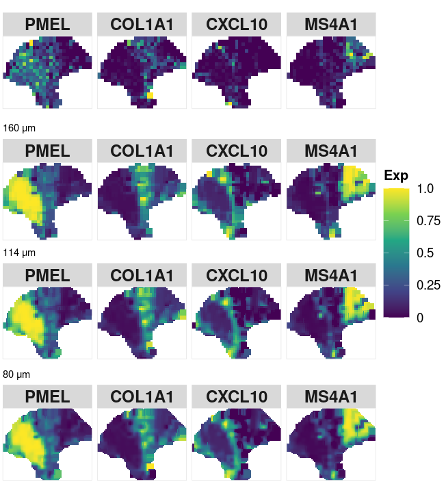

```r
if (save_file) {
  file_name = file.path(home.dir, 'Fig4E_Melanoma_4region_marker_heatmap_impute.pdf')
  cairo_pdf(file_name, height=7.4, width=6.8, onefile=T)
  print(sprintf('figures saved in file %s', file_name))
}

# CARD visualization functions require spatial gene expression dataframe is raw nUMI counts with rows as genes and columns as spots, as the visualization function will normalize nUMI counts by sequencing depth of spots
g_list = list()
# original resolution
g_list[[1]] = CARD::CARD.visualize.gene(
  spatial_expression = gene_numi[, rownames(all_res[['Annotation']])],
  spatial_location = all_res[['Annotation']][, c('x', 'y')],
  gene.visualize = mela_layer_marker,
  colors = NULL,
  NumCols = 4) + theme(legend.position="right") + guides(color=guide_colourbar(title="Exp")) +
  geom_point(aes(color=value), size=3, shape=15, position=position_dodge2(width=0.05))

# 160, 114, 80 μm
for (this_diameter in c('160', '114', '80')) {
  g_list[[length(g_list)+1]] = CARD::CARD.visualize.gene(
    spatial_expression = imputations[['SDePER']][[this_diameter]][['gene_norm_exp']],
    spatial_location = imputations[['SDePER']][[this_diameter]][['loc']],
    gene.visualize = mela_layer_marker,
    colors = NULL,
    NumCols = 4) + theme(legend.position="right") + guides(color=guide_colourbar(title="Exp")) +
    geom_point(aes(color=value), size=3, shape=15, position=position_dodge2(width=0.05)) +
    labs(subtitle = paste(this_diameter, 'μm', sep=' '))
}

ggpubr::ggarrange(plotlist = g_list, ncol=1, nrow=4, common.legend = T, legend = 'right', align = 'v')
```

## 5.8 Figure S17. Heatmap of imputed expression of 4 region-specific marker genes by SDePER and CARD

*PMEL* for Melanoma, *COL1A1* for Stroma, *CXCL10* for LT 2, *MS4A1* for LT 1.

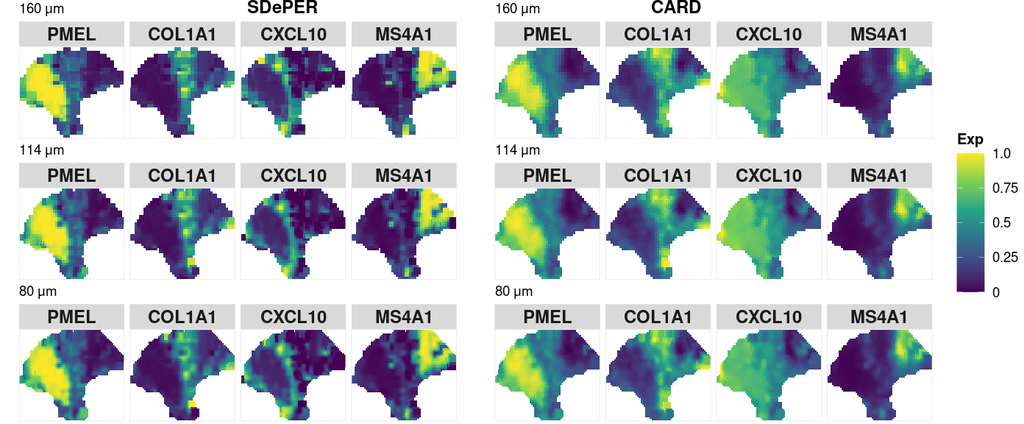

```r
if (save_file) {
  file_name = file.path(home.dir, 'FigS17_Melanoma_4region_marker_heatmap_impute_allmethods.pdf')
  cairo_pdf(file_name, height=6, width=14.5, onefile=T)
  print(sprintf('figures saved in file %s', file_name))
}

# CARD visualization functions require spatial gene expression dataframe is raw nUMI counts with rows as genes and columns as spots, as the visualization function will normalize nUMI counts by sequencing depth of spots
# left panel: SDePER result; right panel: CARD result
# 1st to 3th row: 160, 114, 80 μm
g_list = list()

for (this_diameter in c('160', '114', '80')) {
  for (method_name in c('SDePER', 'CARD')) {
    g_list[[length(g_list)+1]] = CARD::CARD.visualize.gene(
      spatial_expression = imputations[[method_name]][[this_diameter]][['gene_norm_exp']],
      spatial_location = imputations[[method_name]][[this_diameter]][['loc']],
      gene.visualize = mela_layer_marker,
      colors = NULL,
      NumCols = 4) +
      geom_point(aes(color=value), size=3, shape=15, position=position_dodge2(width=0.05)) +
      theme(legend.position="right", plot.subtitle=element_text(size=14)) + guides(color=guide_colourbar(title="Exp")) + labs(subtitle = sprintf('%s μm', this_diameter))
  }
}

ggpubr::ggarrange(plotlist = g_list, ncol=2, nrow=3, labels = c('SDePER', 'CARD'), font.label = list(size=18), vjust = 1, hjust = -3.5, align = 'hv', common.legend = T, legend = 'right')
```

## 5.9 Figure 4F. Heatmap of average imputed expression of 4 region-specific marker genes at 80 μm level

*PMEL* for Melanoma, *COL1A1* for Stroma, *CXCL10* for LT 2, *MS4A1* for LT 1.

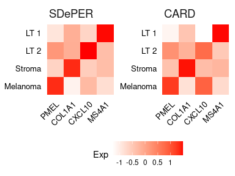

```r
if (save_file) {
  file_name = file.path(home.dir, 'Fig4F_Melanoma_4region_marker_avgExp_heatmap_80μm.pdf')
  cairo_pdf(file_name, height=3, width=4, onefile=T)
  print(sprintf('figures saved in file %s', file_name))
}

plot_df = rbind(avg_exp_layer[['SDePER']][['80']], avg_exp_layer[['CARD']][['80']])
plot_df$anno = factor(plot_df$anno, levels = layer_order)
plot_df$marker = factor(plot_df$marker, levels = mela_layer_marker)
plot_df$Method = factor(plot_df$Method, levels = c('SDePER', 'CARD'))

# plot the scaled gene expression
ggplot(plot_df, aes(x=marker, y=anno, fill=scaled_exp)) +
  geom_tile() +
  scale_fill_gradient(low="white", high="red", breaks=c(-1, -0.5, 0, 0.5, 1), labels=c(-1, -0.5, 0, 0.5, 1), name='Exp') +
  theme_classic() +
  theme(axis.text = element_text(color="black", size=10), axis.text.x = element_text(angle=45, hjust = 1),
        axis.line = element_blank(), axis.ticks = element_blank(), axis.title = element_blank(),
        strip.background = element_rect(size=0), strip.text = element_text(size=14, hjust=0),
        legend.position = "bottom") +
  facet_wrap(.~Method, scales = 'free_y')
```

## 5.10 Figure 4G. Barplot of ratio of average imputed expression of 4 region-specific marker genes at 80 μm level

*PMEL* for Melanoma, *COL1A1* for Stroma, *CXCL10* for LT 2, *MS4A1* for LT 1.

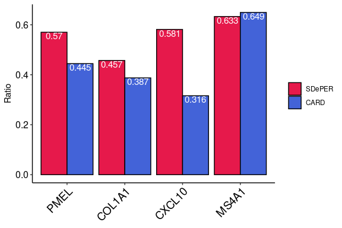

```r
if (save_file) {
  file_name = file.path(home.dir, 'Fig4G_Melanoma_4region_marker_ratio_barplot_80μm.pdf')
  cairo_pdf(file_name, height=4, width=6, onefile=T)
  print(sprintf('figures saved in file %s', file_name))
}

# for each layer marker, calculate the ratio of un-scaled expression in this layer among the expression of all layers
plot_df = rbind(avg_exp_layer[['SDePER']][['80']], avg_exp_layer[['CARD']][['80']])
ratio_df = data.frame(matrix(ncol=3, nrow=0))
colnames(ratio_df) = c('marker', 'Method', 'ratio')

for (method_name in c('SDePER', 'CARD')) {
  for (this_marker in mela_layer_marker) {
    this_layer = names(mela_layer_marker)[which(mela_layer_marker==this_marker)]
    tmp_df =  plot_df %>%
      filter(Method==method_name & marker==this_marker)
    stopifnot(nrow(tmp_df) == length(layer_order))
    this_ratio = tmp_df[tmp_df$anno==this_layer, 'expression', drop=T] / sum(tmp_df$expression)
    ratio_df[nrow(ratio_df)+1, ] = c(this_marker, method_name, this_ratio)
  }
}

ratio_df$marker = factor(ratio_df$marker, levels = mela_layer_marker)
ratio_df$Method = factor(ratio_df$Method, levels = c('SDePER', 'CARD'))
ratio_df$ratio = as.numeric(ratio_df$ratio)

ggplot(ratio_df, aes(x=marker, y=ratio, fill=Method)) +
  geom_bar(stat="identity", color="black", position=position_dodge()) +
  scale_fill_manual(values = c('SDePER'='#e6194b', 'CARD'='#4363d8')) +
  geom_text(aes(label = round(ratio, 3)), position = position_dodge(0.9), vjust=1.1, size=4, color="white") +
  theme_classic() +
  theme(axis.text.y = element_text(color="black", size=12), axis.text.x = element_text(angle=45, hjust=1, size=14, color="black"),
        axis.title.x = element_blank(),
        legend.title = element_blank(), legend.position = "right") +
  ylab("Ratio")
```